# ECON 326 Final Project - Jupyter Notebook Submission

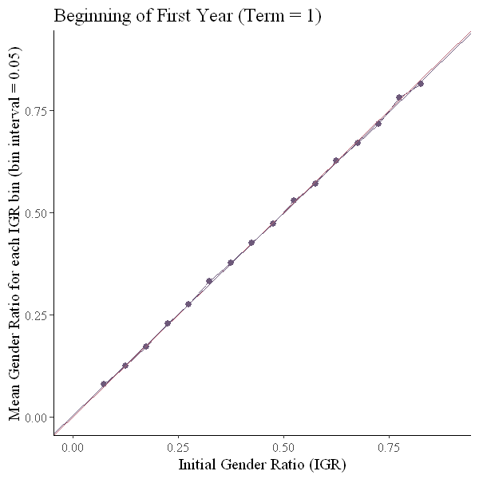

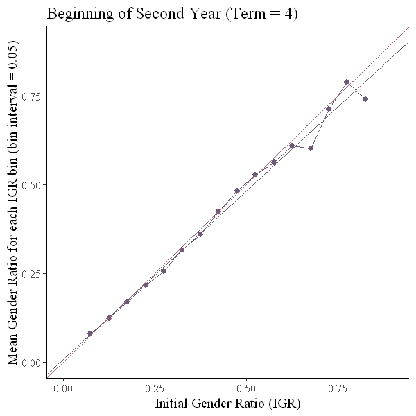

[figure not shown]

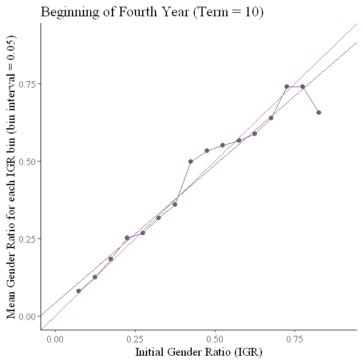

```r
#Viewing the 4 Graphs together
grapht1
grapht4
grapht7
grapht10
```

```r
#SAVING EACH GRAPH:

#Change this directory to wherever you want to save the plots to:
plots_directory <- "/Users/Banana/Desktop/326 Academia Data/GRAPHS FOR 326 PROJECT"

ggsave("CEF_T1.png", plot = grapht1, path = plots_directory)
ggsave("CEF_T4.png", plot = grapht4, path = plots_directory)
ggsave("CEF_T7.png", plot = grapht7, path = plots_directory)
ggsave("CEF_T10.png", plot = grapht10, path = plots_directory)
```

[output not shown]

**Bar Graph by Faculty:**

- Plotting a bar graph that shows the gender ratio by faculty
- Helpful in our analysis to get a sense of which faculties we should look into more

```r
#Setup, also to get a table
faculties <- c("AHS", "ARTS", "ENG", "ENV", "MATH", "SCI", "SE")
faculty_names <- c("Applied Health", "Arts", "Engineering", "Environment", "Math", "Science", "Software Eng.")

mean_f <- w_data %>%
  group_by(Faculty.Group) %>%
  summarise_at(vars(Gender), list(name = mean))

mean_f

#CODE: https://www.statology.org/r-mean-by-group/
```

| Faculty.Group | name |
| --- | --- |
| AHS | 0.6197260 |
| ARTS | 0.5763969 |
| ENG | 0.2227401 |
| ENV | 0.5527221 |
| MATH | 0.3106958 |
| SCI | 0.5815419 |
| SE | 0.1325810 |

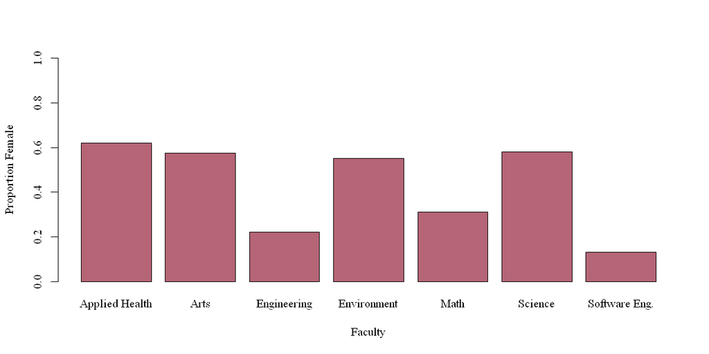

```r
options(repr.plot.width=10, repr.plot.height = 5)

title_graph <- paste("Proportion of female students studying in each faculty, overall (all data years)")

propfemale_faculty <- barplot(mean_f[[2]], names.arg = faculty_names,
        xlab = "Faculty",
        ylab = "Proportion Female",
        #main = "Figure 1",
        col = c_muddymagenta,
        #sub = title_graph,
        #cex.sub = 1.2,
        family = "serif",
       ylim = c(0,1))
```

**Summary Statistics:**

```r
#Create a summary statistics table
#Change "text" to "html"

summary2 <- w_data %>%
    select(Gender, IGR, Study.Year, Study.Term, Data.Year)
stargazer(summary2, type = "text", title = "Table 1: Summary Statistics") #out = "SummaryStatTable.doc"
```

```
Table 1: Summary Statistics
===============================================================
Statistic     N    Mean  St. Dev.  Min  Pctl(25) Pctl(75)  Max
---------------------------------------------------------------
Gender     429,715 0.399  0.490     0      0        1       1
IGR        429,715 0.400  0.209   0.061  0.156    0.563   0.815
Study.Term 429,715 5.589  3.354     1      2        8      13
Data.Year  429,715 5.757  2.299     1      4        8       9
---------------------------------------------------------------
```

## Running Regressions

Adding dummies for most of our controls:

```r
#Add dummy variable for being in school and not on a work term
w_data <- w_data %>%
    mutate(In.School = ifelse(WorkTerm == "Academic Term", 1, 0))

#Add dummy variable for being an international student
w_data <- w_data %>%
    mutate(International = ifelse(Visa.Status == "International", 1, 0))

#Add dummy variable for being a permanent resident
w_data <- w_data %>%
    mutate(PR = ifelse(Visa.Status == "Canadian Permanent Resident", 1, 0))

#Add dummy variable for being a full time student
w_data <- w_data %>%
    mutate(Full.Time = ifelse(Attendance == "Full-Time", 1, 0))
```

## First: Gender ~ IGR + Study.Term

Main model that we use:

```r
#Getting the specifications for our first model
s1 = lm(Gender ~ IGR + Study.Term, data = w_data)
s2 = lm(Gender ~ IGR*Study.Term, data = w_data)
s3 = lm(Gender ~ IGR*Study.Term + International + PR, data = w_data)
s4 = lm(Gender ~ IGR*Study.Term + In.School + Full.Time, data = w_data)
s5 = lm(Gender ~ IGR*Study.Term + International + PR + In.School + Full.Time, data = w_data)
```

```r
#Creating a regression table using stargazer
#NOTE: Replace "text" with "html" and add code at the end to export it

stargazer(s1, s2, s3, s4, s5, title = "Comparison of Regressions", align = TRUE, type = "text",
         keep.stat = c("n", "rsq")) #out = "Model1_FirstTable.doc"
```

```
Comparison of Regressions
==============================================================
                             Dependent variable:
               -----------------------------------------------
                                   Gender
                 (1)      (2)       (3)       (4)       (5)
--------------------------------------------------------------
IGR            0.989*** 0.997*** 1.019***  0.999***  1.024***
               (0.003)  (0.006)   (0.006)   (0.006)   (0.006)

Study.Term     0.0005** 0.001**  0.002***   0.001**  0.002***
               (0.0002) (0.0004) (0.0004)  (0.0004)  (0.0004)

International                    0.078***            0.079***
                                  (0.002)             (0.002)

PR                               0.043***            0.043***
                                  (0.002)             (0.002)

In.School                                   -0.003*  -0.007***
                                            (0.002)   (0.002)

Full.Time                                  -0.014*** -0.016***
                                            (0.004)   (0.004)

IGR:Study.Term           -0.001  -0.002**   -0.002*  -0.003***
                        (0.001)   (0.001)   (0.001)   (0.001)

Constant        0.001    -0.002  -0.026*** 0.014***   -0.007
               (0.002)  (0.003)   (0.003)   (0.005)   (0.005)

--------------------------------------------------------------
Observations   429,715  429,715   429,715   429,715   429,715
R2              0.177    0.177     0.180     0.177     0.180
==============================================================
Note:                              *p<0.1; **p<0.05; ***p<0.01
```

**Potential Issues**

- Multicollinearity
- Heteroskedasticity

Checking for multicollinearity:

```r
#Checking the VIFs for multicollinearity
vif(s1, type = "terms")
vif(s2, type = "terms")
vif(s3, type = "terms")
vif(s4, type = "terms")
vif(s5, type = "terms")
```

**IGR**

1.00028585695413

**Study.Term**

1.00028585695413

**IGR**

3.79390417969656

**Study.Term**

4.76358602336531

**IGR:Study.Term**

7.44729331974437

**IGR**

3.82596509829074

**Study.Term**

4.77084243571892

**International**

1.03040784531066

**PR**

1.02350315809027

**IGR:Study.Term**

7.44974513292212

**IGR**

3.9314102416718

**Study.Term**

4.76413294443653

**In.School**

1.09470228114554

**Full.Time**

1.04424275470918

**IGR:Study.Term**

7.52255297112906

**IGR**

3.97246748191924

**Study.Term**

4.77162214502219

**International**

1.03528922207202

**PR**

1.02381658366841

**In.School**

1.09996636697044

**Full.Time**

1.04434488100503

**IGR:Study.Term**

7.52681106592374

Because we use a linear probability model, we are going to run into heteroskedasticity as an issue.

We can formally run the White Test to diagnose this, although we already know the outcome.

**White Test:**

$\hat{\epsilon}_{i}^{2} = \delta_{0} + \delta_{1}\hat{Y}_{1} + \delta_{2}\hat{Y}_{1}^{2} + \epsilon_i$

```r
#Using our final (and most complete) specification: s5

residuals_sq_s5 = s5$residuals^2

y_hat_s5 <- predict(s5)

#White

White_s5 <- lm(residuals_sq_s5 ~ y_hat_s5 + I(y_hat_s5^2), data = w_data)

stargazer(White_s5, title = "White Test for Model 1", align = TRUE, type = "text",
          keep.stat = c("n", "rsq")) #, out = "WhiteTestModel1.doc")

#Looks like we fail the White Test - unsurprisingly
#(the coefficients are both statistically significant and different from 0)
```

```
White Test for Model 1
========================================
                 Dependent variable:
             ---------------------------
                   residuals_sq_s5
----------------------------------------
y_hat_s5              0.933***
                       (0.006)

I(y_hat_s52)          -0.909***
                       (0.007)

Constant              0.008***
                       (0.001)

----------------------------------------
Observations           429,715
R2                      0.124
========================================
Note:        *p<0.1; **p<0.05; ***p<0.01
```

**Robust Standard Errors:**

```r
se_s1 <- sqrt(diag(vcovHC(s1, type = "HC1")))
stargazer(s1, s1, se = list(NULL, se_s1), type = "text", column.labels=c("default","robust"))

se_s2 <- sqrt(diag(vcovHC(s2, type = "HC1")))
stargazer(s2, s2, se = list(NULL, se_s2), type = "text", column.labels=c("default","robust"))

se_s3 <- sqrt(diag(vcovHC(s3, type = "HC1")))
stargazer(s3, s3, se = list(NULL, se_s3), type = "text", column.labels=c("default","robust"))

se_s4 <- sqrt(diag(vcovHC(s4, type = "HC1")))
stargazer(s4, s4, se = list(NULL, se_s4), type = "text", column.labels=c("default","robust"))

se_s5 <- sqrt(diag(vcovHC(s5, type = "HC1")))
stargazer(s5, s5, se = list(NULL, se_s5), type = "text", column.labels=c("default","robust"))
```

```
==============================================================
                                      Dependent variable:
                                  ----------------------------
                                             Gender
                                     default        robust
                                       (1)            (2)
--------------------------------------------------------------
IGR                                  0.989***      0.989***
                                     (0.003)        (0.003)

Study.Term                           0.0005**      0.0005**
                                     (0.0002)      (0.0002)

Constant                              0.001          0.001
                                     (0.002)        (0.002)

--------------------------------------------------------------
Observations                         429,715        429,715
R2                                    0.177          0.177
Adjusted R2                           0.177          0.177
Residual Std. Error (df = 429712)     0.444          0.444
F Statistic (df = 2; 429712)      46,303.030***  46,303.030***
==============================================================
Note:                              *p<0.1; **p<0.05; ***p<0.01

==============================================================
                                      Dependent variable:
                                  ----------------------------
                                             Gender
                                     default        robust
                                       (1)            (2)
--------------------------------------------------------------
IGR                                  0.997***      0.997***
                                     (0.006)        (0.006)

Study.Term                           0.001**       0.001***
                                     (0.0004)      (0.0004)

IGR:Study.Term                        -0.001        -0.001*
                                     (0.001)        (0.001)
```

[output cut: 105 more lines]

```

IGR:Study.Term                      -0.003***      -0.003***
                                     (0.001)        (0.001)

Constant                              -0.007        -0.007
                                     (0.005)        (0.005)

--------------------------------------------------------------
Observations                         429,715        429,715
R2                                    0.180          0.180
Adjusted R2                           0.180          0.180
Residual Std. Error (df = 429707)     0.443          0.443
F Statistic (df = 7; 429707)      13,494.510***  13,494.510***
==============================================================
Note:                              *p<0.1; **p<0.05; ***p<0.01
```

## Second: Gender ~ Faculty + Study.Term

Secondary model that we use

```r
#Create new dataset for working with here
w_data_fac <- w_data

unique(w_data_fac$Faculty.Group)
```

1. ARTS

2. ENG

3. SCI

4. MATH

5. ENV

6. AHS

7. SE

**Levels**:**

1. 'AHS'

2. 'ARTS'

3. 'CFM'

4. 'ENG'

5. 'ENV'

6. 'MATH'

7. 'REN'

8. 'SCI'

9. 'SE'

10. 'THL'

```r
#Adding dummy variables for each faculty

w_data_fac <- w_data_fac %>%
    mutate(Applied.Health = ifelse(Faculty.Group == "AHS", 1, 0)) %>%
    mutate(Arts = ifelse(Faculty.Group == "ARTS", 1, 0)) %>%
    mutate(Engineering = ifelse(Faculty.Group == "ENG", 1, 0)) %>%
    mutate(Environment = ifelse(Faculty.Group == "ENV", 1, 0)) %>%
    mutate(Math = ifelse(Faculty.Group == "MATH", 1, 0)) %>%
    mutate(Science = ifelse(Faculty.Group == "SCI", 1, 0)) %>%
    mutate(Software.Engineering = ifelse(Faculty.Group == "SE", 1, 0))
```

```r
faculties <- c("AHS", "ARTS", "ENG", "ENV", "MATH", "SCI", "SE")
faculty_names <- c("Applied Health", "Arts", "Engineering", "Environment", "Math", "Science", "Software Eng.")

mean_f <- w_data %>%
  group_by(Faculty.Group) %>%
  summarise_at(vars(Gender), list(name = mean))

mean_f

#CODE: https://www.statology.org/r-mean-by-group/
```

| Faculty.Group | name |
| --- | --- |
| AHS | 0.6197260 |
| ARTS | 0.5763969 |
| ENG | 0.2227401 |
| ENV | 0.5527221 |
| MATH | 0.3106958 |
| SCI | 0.5815419 |
| SE | 0.1325810 |

Running regressions:

```r
sp2a = lm(Gender ~ Study.Term + International + PR + In.School + Full.Time + Applied.Health*Study.Term + Arts*Study.Term + Engineering*Study.Term + Math*Study.Term + Science*Study.Term + Software.Engineering*Study.Term, data = w_data_fac)
sp2b = lm(Gender ~  Study.Term + Applied.Health*Study.Term + Arts*Study.Term + Engineering*Study.Term + Math*Study.Term + Science*Study.Term + Software.Engineering*Study.Term, data = w_data_fac)
sp2c = lm(Gender ~  Study.Term + In.School + Full.Time + Applied.Health*Study.Term + Arts*Study.Term + Engineering*Study.Term + Math*Study.Term + Science*Study.Term + Software.Engineering*Study.Term, data = w_data_fac)

stargazer(sp2a, sp2b, sp2c, title = "Comparison of Regressions", align = TRUE, type = "text",
         keep.stat = c("n", "rsq")) #out = "Model2_table.doc")
```

```
Comparison of Regressions
=============================================================
                                     Dependent variable:
                                -----------------------------
                                           Gender
                                   (1)       (2)       (3)
-------------------------------------------------------------
Study.Term                      0.004***  0.004***  0.004***
                                 (0.001)   (0.001)   (0.001)

International                   0.097***
                                 (0.002)

PR                              0.046***
                                 (0.002)

In.School                        -0.002               0.002
                                 (0.002)             (0.002)

Full.Time                       -0.028***           -0.027***
                                 (0.004)             (0.004)

Applied.Health                  0.100***  0.098***  0.098***
                                 (0.007)   (0.007)   (0.007)

Arts                            0.088***  0.092***  0.091***
                                 (0.006)   (0.006)   (0.006)

Engineering                     -0.303*** -0.291*** -0.290***
                                 (0.006)   (0.006)   (0.006)

Math                            -0.223*** -0.187*** -0.187***
                                 (0.006)   (0.006)   (0.006)

Science                         0.044***  0.044***  0.044***
                                 (0.006)   (0.006)   (0.006)

Software.Engineering            -0.388*** -0.376*** -0.375***
                                 (0.010)   (0.010)   (0.010)

```

[output cut: 11 more lines]

```

Study.Term:Science              -0.002**  -0.002**  -0.002***
                                 (0.001)   (0.001)   (0.001)

Study.Term:Software.Engineering -0.006*** -0.007*** -0.007***
                                 (0.002)   (0.002)   (0.002)

Constant                        0.549***  0.524***  0.550***
                                 (0.007)   (0.005)   (0.007)

-------------------------------------------------------------
Observations                     429,715   429,715   429,715
R2                                0.122     0.118     0.118
=============================================================
Note:                             *p<0.1; **p<0.05; ***p<0.01
```

Issues:

- Multicollinearity (again)
- Heteroskedasticity

```r
#Getting VIF
vif(sp2a)
vif(sp2b)
vif(sp2c)
```

**Study.Term**

12.3442234430957

**International**

1.13209860148637

**PR**

1.03863705942562

**In.School**

1.16040370689717

**Full.Time**

1.05865797739808

**Applied.Health**

7.41895685961277

**Arts**

9.2483642052093

**Engineering**

15.1074885168152

**Math**

13.0020219126009

**Science**

11.0218918477343

**Software.Engineering**

5.48361349424771

**Study.Term:Applied.Health**

7.13583906273557

**Study.Term:Arts**

7.55206226662743

**Study.Term:Engineering**

13.3656395654517

**Study.Term:Math**

11.8131153369917

**Study.Term:Science**

10.7106611240766

**Study.Term:Software.Engineering**

5.19887615616083

**Study.Term**

12.1971787254744

**Applied.Health**

7.418052773947

**Arts**

9.24048397271122

**Engineering**

14.7442211198558

**Math**

12.7454006307931

**Science**

11.0156289228931

**Software.Engineering**

5.4553158695578

**Study.Term:Applied.Health**

7.12755206856661

**Study.Term:Arts**

7.54493872219379

**Study.Term:Engineering**

13.2039219636056

**Study.Term:Math**

11.7736106295131

**Study.Term:Science**

10.6602161630934

**Study.Term:Software.Engineering**

5.19036236489545

**Study.Term**

12.3354933007829

**In.School**

1.1566217032312

**Full.Time**

1.0586444842272

**Applied.Health**

7.41858441173812

**Arts**

9.24707256091351

**Engineering**

15.0622367411252

**Math**

12.7481478684573

**Science**

11.0216599224038

**Software.Engineering**

5.47806018342544

**Study.Term:Applied.Health**

7.13379676090738

**Study.Term:Arts**

7.54802466761613

**Study.Term:Engineering**

13.3507443916332

**Study.Term:Math**

11.7749116743985

**Study.Term:Science**

10.7078914590221

**Study.Term:Software.Engineering**

5.19722822915733

```r
se_sp2a <- sqrt(diag(vcovHC(sp2a, type = "HC1")))
stargazer(sp2a, sp2a, se = list(NULL, se_sp2a), type = "text", column.labels=c("default","robust"))

se_sp2b <- sqrt(diag(vcovHC(sp2b, type = "HC1")))
stargazer(sp2b, sp2b, se = list(NULL, se_sp2b), type = "text", column.labels=c("default","robust"))

se_sp2c <- sqrt(diag(vcovHC(sp2c, type = "HC1")))
stargazer(sp2c, sp2c, se = list(NULL, se_sp2c), type = "text", column.labels=c("default","robust"))
```

```
==============================================================
                                      Dependent variable:
                                  ----------------------------
                                             Gender
                                     default        robust
                                       (1)            (2)
--------------------------------------------------------------
Study.Term                           0.004***      0.004***
                                     (0.001)        (0.001)

International                        0.097***      0.097***
                                     (0.002)        (0.002)

PR                                   0.046***      0.046***
                                     (0.002)        (0.003)

In.School                             -0.002        -0.002
                                     (0.002)        (0.002)

Full.Time                           -0.028***      -0.028***
                                     (0.004)        (0.004)

Applied.Health                       0.100***      0.100***
                                     (0.007)        (0.008)

Arts                                 0.088***      0.088***
                                     (0.006)        (0.007)

Engineering                         -0.303***      -0.303***
                                     (0.006)        (0.006)

Math                                -0.223***      -0.223***
                                     (0.006)        (0.006)

Science                              0.044***      0.044***
                                     (0.006)        (0.007)

Software.Engineering                -0.388***      -0.388***
                                     (0.010)        (0.009)

```

[output cut: 136 more lines]

```

Study.Term:Software.Engineering     -0.007***      -0.007***
                                     (0.002)        (0.001)

Constant                             0.550***      0.550***
                                     (0.007)        (0.007)

--------------------------------------------------------------
Observations                         429,715        429,715
R2                                    0.118          0.118
Adjusted R2                           0.118          0.118
Residual Std. Error (df = 429699)     0.460          0.460
F Statistic (df = 15; 429699)      3,849.440***  3,849.440***
==============================================================
Note:                              *p<0.1; **p<0.05; ***p<0.01
```

## Third: Investigating Specific Programs (Gender ~ Study.Term only, for select programs)

ROBUSTNESS CHECK:

Should use:

- 1 program with LOW gender ratio: Computer Engineering
- 1 program with MEDIUM gender ratio: Civil Engineering
- 1 program with HIGH gender ratio: Chemical Engineering

**Computer Engineering**

- Program with a *low* gender ratio, relative to all engineering

```r
#See: Low gender ratio
mean(filter(w_data, Program.Grouping == "Computer Engineering")$Gender)
```

0.100073855243722

```r
w_data_compeng <- w_data %>% filter(Program.Grouping == "Computer Engineering")
```

```r
reg_compeng = lm(Gender ~ Study.Term + In.School + Full.Time + PR + International, data = w_data_compeng)
summary(reg_compeng)
```

```
Call:
lm(formula = Gender ~ Study.Term + In.School + Full.Time + PR +
    International, data = w_data_compeng)

Residuals:
     Min       1Q   Median       3Q      Max
-0.17431 -0.09940 -0.08920 -0.07545  0.93353

Coefficients:
                Estimate Std. Error t value Pr(>|t|)
(Intercept)    0.0111878  0.0590722   0.189    0.850
Study.Term    -0.0029938  0.0007149  -4.188 2.83e-05 ***
In.School      0.0042190  0.0047564   0.887    0.375
Full.Time      0.0869918  0.0587036   1.482    0.138
PR             0.0469998  0.0074307   6.325 2.60e-10 ***
International  0.0749028  0.0071083  10.537  < 2e-16 ***
---
Signif. codes:  0 '***' 0.001 '**' 0.01 '*' 0.05 '.' 0.1 ' ' 1

Residual standard error: 0.2986 on 16242 degrees of freedom
Multiple R-squared:  0.01024,	Adjusted R-squared:  0.009934
F-statistic:  33.6 on 5 and 16242 DF,  p-value: < 2.2e-16
```

**Civil Engineering**

- Program with a *medium* gender ratio, relative to other engineering programs!

```r
#See: Medium gender ratio
mean(filter(w_data, Program.Grouping == "Civil Engineering")$Gender)
```

0.269043492613683

```r
w_data_civileng <- w_data %>% filter(Program.Grouping == "Civil Engineering")
```

```r
reg_civileng = lm(Gender ~ Study.Term + In.School + Full.Time + PR + International, data = w_data_civileng)
summary(reg_civileng)
```

```
Call:
lm(formula = Gender ~ Study.Term + In.School + Full.Time + PR +
    International, data = w_data_civileng)

Residuals:
    Min      1Q  Median      3Q     Max
-0.3693 -0.2715 -0.2442  0.6487  0.7830

Coefficients:
               Estimate Std. Error t value Pr(>|t|)
(Intercept)    0.282820   0.114914   2.461   0.0139 *
Study.Term    -0.005445   0.001241  -4.387 1.16e-05 ***
In.School      0.001764   0.008136   0.217   0.8283
Full.Time     -0.002241   0.114236  -0.020   0.9843
PR             0.092425   0.013758   6.718 1.93e-11 ***
International  0.079844   0.011964   6.674 2.60e-11 ***
---
Signif. codes:  0 '***' 0.001 '**' 0.01 '*' 0.05 '.' 0.1 ' ' 1

Residual standard error: 0.4417 on 12111 degrees of freedom
Multiple R-squared:  0.008294,	Adjusted R-squared:  0.007885
F-statistic: 20.26 on 5 and 12111 DF,  p-value: < 2.2e-16
```

**Chemical Engineering**

- Program with a *high* gender ratio, relative to all engineering programs

```r
#See: Medium gender ratio
mean(filter(w_data, Program.Grouping == "Chemical Engineering")$Gender)
```

0.34644033806045

```r
w_data_chemeng <- w_data %>% filter(Program.Grouping == "Chemical Engineering")
```

```r
reg_chemeng = lm(Gender ~ Study.Term + In.School + Full.Time + PR + International, data = w_data_chemeng)
summary(reg_chemeng)
```

```
Call:
lm(formula = Gender ~ Study.Term + In.School + Full.Time + PR +
    International, data = w_data_chemeng)

Residuals:
    Min      1Q  Median      3Q     Max
-0.4004 -0.3522 -0.3274  0.6392  0.7944

Coefficients:
               Estimate Std. Error t value Pr(>|t|)
(Intercept)    0.256593   0.112938   2.272  0.02310 *
Study.Term    -0.004969   0.001258  -3.949 7.88e-05 ***
In.School      0.008588   0.008123   1.057  0.29045
Full.Time      0.110520   0.112276   0.984  0.32496
PR            -0.023647   0.014046  -1.684  0.09230 .
International  0.029638   0.011271   2.629  0.00856 **
---
Signif. codes:  0 '***' 0.001 '**' 0.01 '*' 0.05 '.' 0.1 ' ' 1

Residual standard error: 0.4755 on 13956 degrees of freedom
Multiple R-squared:  0.00204,	Adjusted R-squared:  0.001682
F-statistic: 5.705 on 5 and 13956 DF,  p-value: 2.905e-05
```

**All together now...**

```r
stargazer(reg_compeng, reg_civileng, reg_chemeng, title = "Engineering: Comparison of 3 Programs",
        align = TRUE, type = "text",
        column.labels = c("Computer", "Civil", "Chemical"),
        keep.stat = c("n", "rsq")) #out = "Robustness_table.doc")
```

```
Engineering: Comparison of 3 Programs
===========================================
                   Dependent variable:
              -----------------------------
                         Gender
              Computer    Civil   Chemical
                 (1)       (2)       (3)
-------------------------------------------
Study.Term    -0.003*** -0.005*** -0.005***
               (0.001)   (0.001)   (0.001)

In.School       0.004     0.002     0.009
               (0.005)   (0.008)   (0.008)

Full.Time       0.087    -0.002     0.111
               (0.059)   (0.114)   (0.112)

PR            0.047***  0.092***   -0.024*
               (0.007)   (0.014)   (0.014)

International 0.075***  0.080***  0.030***
               (0.007)   (0.012)   (0.011)

Constant        0.011    0.283**   0.257**
               (0.059)   (0.115)   (0.113)

-------------------------------------------
Observations   16,248    12,117    13,962
R2              0.010     0.008     0.002
===========================================
Note:           *p<0.1; **p<0.05; ***p<0.01
```

**Checking for issues and adding robust SEs:**

```r
#Multicollinearity check
vif(reg_compeng)
vif(reg_civileng)
vif(reg_chemeng)
```

**Study.Term**

1.02391232275398

**In.School**

1.01089484235587

**Full.Time**

1.00320393589758

**PR**

1.02132430349669

**International**

1.03154932800843

**Study.Term**

1.00621740276355

**In.School**

1.00523233008556

**Full.Time**

1.00195367193331

**PR**

1.01753943885095

**International**

1.01654752604827

**Study.Term**

1.00396135658184

**In.School**

1.00317900546084

**Full.Time**

1.00247905837817

**PR**

1.0189936244705

**International**

1.01876133204867

```r
#Getting robust SEs
se_comp <- sqrt(diag(vcovHC(reg_compeng, type = "HC1")))
stargazer(reg_compeng, reg_compeng, se = list(NULL, se_comp), type = "text", column.labels=c("default","robust"))

se_civil <- sqrt(diag(vcovHC(reg_civileng, type = "HC1")))
stargazer(reg_civileng, reg_civileng, se = list(NULL, se_civil), type = "text", column.labels=c("default","robust"))

se_chem <- sqrt(diag(vcovHC(reg_chemeng, type = "HC1")))
stargazer(reg_chemeng, reg_chemeng, se = list(NULL, se_chem), type = "text", column.labels=c("default","robust"))
```

```
=============================================================
                                     Dependent variable:
                                 ----------------------------
                                            Gender
                                    default        robust
                                      (1)            (2)
-------------------------------------------------------------
Study.Term                         -0.003***      -0.003***
                                    (0.001)        (0.001)

In.School                            0.004          0.004
                                    (0.005)        (0.005)

Full.Time                            0.087        0.087***
                                    (0.059)        (0.006)

PR                                  0.047***      0.047***
                                    (0.007)        (0.008)

International                       0.075***      0.075***
                                    (0.007)        (0.008)

Constant                             0.011          0.011
                                    (0.059)        (0.009)

-------------------------------------------------------------
Observations                         16,248        16,248
R2                                   0.010          0.010
Adjusted R2                          0.010          0.010
Residual Std. Error (df = 16242)     0.299          0.299
F Statistic (df = 5; 16242)        33.604***      33.604***
=============================================================
Note:                             *p<0.1; **p<0.05; ***p<0.01

=============================================================
                                     Dependent variable:
                                 ----------------------------
                                            Gender
                                    default        robust
                                      (1)            (2)
```

[output cut: 46 more lines]

```

International                       0.030***      0.030***
                                    (0.011)        (0.011)

Constant                            0.257**       0.257***
                                    (0.113)        (0.099)

-------------------------------------------------------------
Observations                         13,962        13,962
R2                                   0.002          0.002
Adjusted R2                          0.002          0.002
Residual Std. Error (df = 13956)     0.475          0.475
F Statistic (df = 5; 13956)         5.705***      5.705***
=============================================================
Note:                             *p<0.1; **p<0.05; ***p<0.01
```

## Additional Graphs and Tables

**Heteroskedasticity "eyeball" checks:**

The below graphs take a long time to generate (lots of data points), and so they should be run last.

**Residuals Squared for Model 1**

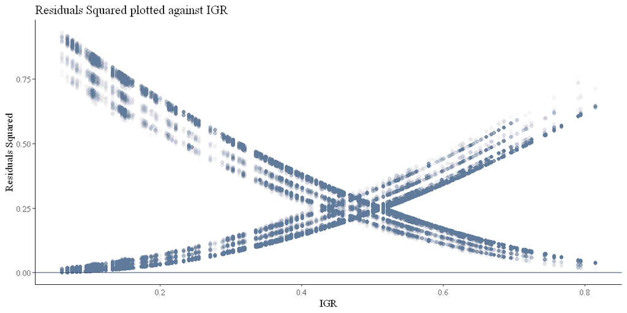

```r
#Plotting the residuals
#Careful running this cell, it takes a while

reg_e_IGR <- lm(s5$residuals ~ IGR, data = w_data) #To get simple regression line, for plotting
beta_e_IGR <- coef(reg_e_IGR)[[2]]
int_e_IGR <- coef(reg_e_IGR)[[1]]


ggplot(data = cbind(w_data, s5$residuals), aes(x = IGR, y = (s5$residuals)^2)) +
geom_point(alpha = 0.01, color = "#355070") +
theme_classic() +
labs(x = "IGR", y = "Residuals Squared") +
geom_abline(slope = beta_e_IGR, intercept = int_e_IGR, color = "#355070") +
ggtitle("Residuals Squared plotted against IGR") +
theme(text=element_text(size=12,
       family="serif"))
```

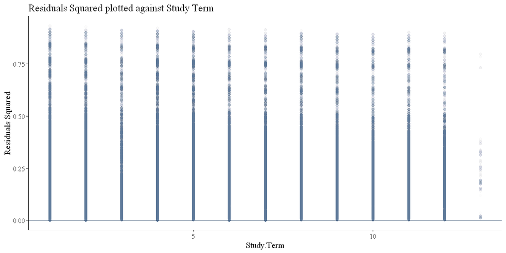

```r
#Residuals against Study.Term
#Careful, this one also takes a while

reg_e_ST <- lm(s5$residuals ~ Study.Term, data = w_data) #To get simple regression line, for plotting
beta_e_ST <- coef(reg_e_ST)[[2]]
int_e_ST <- coef(reg_e_ST)[[1]]

ggplot(data = cbind(w_data, s5$residuals), aes(x = Study.Term, y = (s5$residuals)^2)) +
theme_classic() +
geom_point(alpha = 0.01, color = "#355070") + labs(x = "Study.Term", y = "Residuals Squared") +
geom_abline(slope = beta_e_ST, intercept = int_e_ST, color = "#355070") +
ggtitle("Residuals Squared plotted against Study Term") +
theme(text=element_text(size=12,
       family="serif"))
```